# Day 2 Instructor Version

#### Objectives and Motivation

We are hoping that you both glean something about American politics, while implementing your new graphing tools!

In the US, political party and political ideology are thought to be very closely connected. With people who are more conservative being Republicans, and those that are more liberal being Democrats. Just because the is true on average, doesn’t mean that it true for all groups. Lets investigate this!

##### Research Question:

**Does the distribution of party ID and ideology look different racial groups? Specifically, does the distribution of party ID and ideology differ for those are Black versus those that aren’t?**

Load in our packages.

```r
library(pander)
library(mosaic)
library(tidyverse)
library(gridExtra)
```

# Read in our data

```r
cces_2016 <- read.csv("~/Desktop/R Things/bootcamp/day_2/cces_2016.csv")
```

*Identify your variables of interest for this question. Use your codebook! :)*

I want to use the “black”, “idioligy”, and “partyid” varaibuls to do this analaisis.

# Data Exploration

What is the mean of ideology? What does this mean? Insert an explanation below.

```r
mean(cces_2016$ideology, na.rm = TRUE)
```

```
## [1] 0.2247402
```

What is the median of ideology?

```r
median(cces_2016$ideology, na.rm = TRUE)
```

```
## [1] 1
```

What is the standard deviation of ideology?

```r
sd(cces_2016$ideology, na.rm = TRUE)
```

```
## [1] 1.29914
```

Try using the summary() function to look at all of the above for ideology!

```r
summary(cces_2016$ideology)
```

```
##    Min. 1st Qu.  Median    Mean 3rd Qu.    Max.    NA's
##  -2.000  -1.000   1.000   0.225   1.000   2.000   19766
```

Looking at all of these numbers, what can you say about the distribution, center, and spread of ideology?

# Graphing

Make a histogram of ideology, does the histogram confirm or refute what you thought ideology looked like based on the numbers?

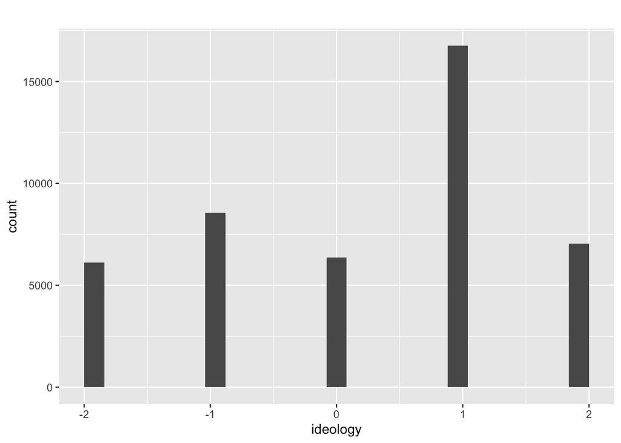

```r
ggplot(data = cces_2016, aes(x = ideology)) +
       geom_histogram(binwidth = 0.16) +
       labs(title = "")
```

Make a graph with at least two variables of interest that are relevant to this question.

*Hint: Box Plots or Violin Plots would be appropriate here.*

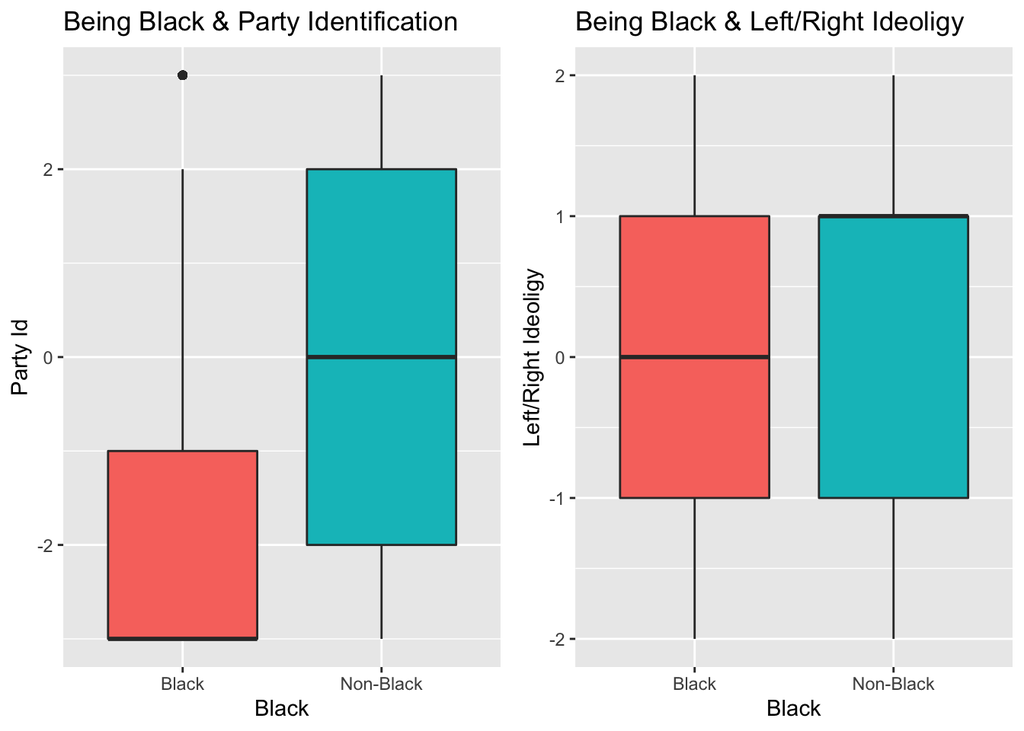

```r
plot1<-ggplot(data = cces_2016, aes(x = black, y = partyid)) +
  geom_boxplot(aes(fill = black), show.legend = FALSE) +
  theme(legend.title = element_blank()) +
  labs(title = "Being Black & Party Identification", x = "Black", y = "Party Id")


plot2<-ggplot(data = cces_2016, aes(x = black, y = ideology)) +
  geom_boxplot(aes(fill = black), show.legend = FALSE) +
  labs(title = "Being Black & Left/Right Ideoligy", x = "Black", y = "Left/Right Ideoligy")

grid.arrange(plot1, plot2, nrow = 1)
```

# Perform a T-Test

We want to see if there is a systematic difference between the distribution of party ID and ideology for Black and Non-Black individuals. Perform the t-tests.

```r
t.test(partyid~black, cces_2016)
```

```
##
##  Welch Two Sample t-test
##
## data:  partyid by black
## t = -96.782, df = 12708, p-value < 2.2e-16
## alternative hypothesis: true difference in means is not equal to 0
## 95 percent confidence interval:
##  -1.835604 -1.762726
## sample estimates:
##     mean in group Black mean in group Non-Black
##              -2.0257539              -0.2265891
```

```r
t.test(ideology~black, cces_2016)
```

```
##
##  Welch Two Sample t-test
##
## data:  ideology by black
## t = -9.4141, df = 7862.5, p-value < 2.2e-16
## alternative hypothesis: true difference in means is not equal to 0
## 95 percent confidence interval:
##  -0.2032645 -0.1332031
## sample estimates:
##     mean in group Black mean in group Non-Black
##              0.07860781              0.24684162
```